# Schei Final Blogpost

Sine Schei

2022-12-29

# Introduction

This dataset on a co-offending London youth gang can be accessed [here](http://www.casos.cs.cmu.edu/tools/datasets/external/index.php). The dataset is also available through the R-package `networkdata` as `covert_28`. For the analysis, I have used the data directly loaded from that package. It consists of 54 nodes and 8 attributes: Age, Birthplace, Residence, Arrests, Convictions, Prison, Music & Ranking.

The data has laid the groundwork for much interesting research already. In particular, authors [McCuish, Bouchard, and Corrado](https://heinonline.org/HOL/Page?lname=&public=false&collection=journals&handle=hein.journals/jccj31&men_hide=false&men_tab=toc&kind=&page=319) looked at the ethnic homophily in the network.

# Theoretical Framework and Hypothesis

[Criminal organizations](https://www.sciencedirect.com/science/article/pii/S0049089X21001344) have become more flexible than before. However, *gangs* remain less flexible due to them being heavily connected to specific territories, [due to opportunity costs](https://www.sciencedirect.com/science/article/pii/S0049089X21001344). The cohesion and structure of a gang relates to their “[organizational survival.](https://www.sciencedirect.com/science/article/pii/S0049089X21001344)” One important aspect of the structure of a criminal organization, especially in the case of co-offending, is therefore who decides to commit crimes with who. The hypothesis I want to test in this paper is therefore:

- Individuals who have been imprisoned are more likely to co-offend with other individuals who have been imprisoned

The aim with this hypothesis is to uncover whether the seriousness of a crime, measured through the variable imprisonment, will influence how others in the network decide to co-offend with you.

As the edges in this network represent the co-offending patterns between the 54 individuals in this youth gang based in London, I wanted to explore what motivates the decision to co-offend with someone. From the visualization of the network below, with fictive names, there is no immediately evident pattern between those who have been to prison and not.

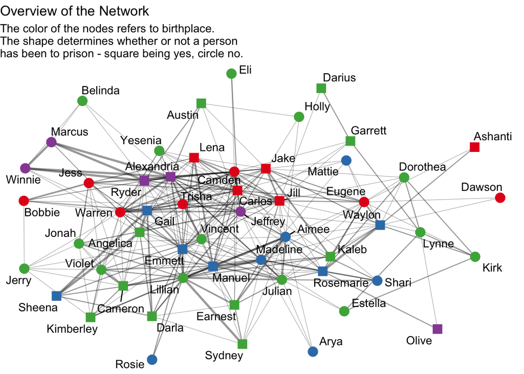

# The Model

The question will be answered by use of an ERGM - Exponential Random Graph Model. An [ERGM](https://eehh-stanford.github.io/SNA-workshop/ergm-intro.html#what-is-a-random-graph), a model taking into account both local and structural effects in a network.

The `edges` and `gwesp` parameters are added to the model to retain the structure of the observed data. The `nodematch` is added to observe whether or not those who have been, or not been, to prison, are more likely to form ties with each other. The model I use is as follows:

`complete.ergm <- ergm(londongang1 ~ edges + nodematch("Prison", diff=FALSE, keep=NULL, levels=NULL) + gwesp(0.3, fixed = T))`

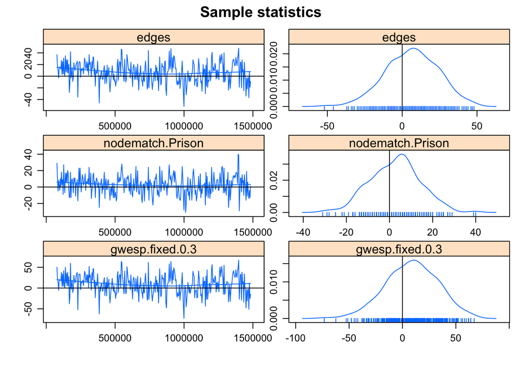

# The results of the ERGM

The model converged with 99% confidence, and the results are in table 1. The AIC score seems high, although it is a relative parameter and thus nothing definitive can be said without comparison. Not surprisingly, the `edges` and `gwesp` measures are shown to be significant with p-values < 0.01. However, the prison attribute has a p-value > 0.1 and is thus not significant.

ERGM results table

|  | ERGM |
| --- | --- |
| edges | -8.60*** |
|  | (1.00) |
| nodematch.Prison | 0.07 |
|  | (0.13) |
| gwesp.fixed.0.3 | 4.89*** |
|  | (0.72) |
| AIC | 1396.61 |
| BIC | 1412.41 |
| Log Likelihood | -695.30 |

***p < 0.01; **p < 0.05; *p < 0.1

# Results and Goodness of Fit

The lack of significance for the prison attribute means that we can not confirm the hypothesis. Furthermore, the GOF shows that the ERGM model needs to be changed to more closely resemble the observed data. It is important to keep in mind that even though an ERGM model may converge and show significant results on some arguments, this does not equal a fit to the observed data. It will therefore be important to continue to work on a model with a better goodness of fit to more thoroughly analyze this hypothesis. In particular, we see that this model caused a very poor fit for the edge-wise shared partners and the degree distribution.

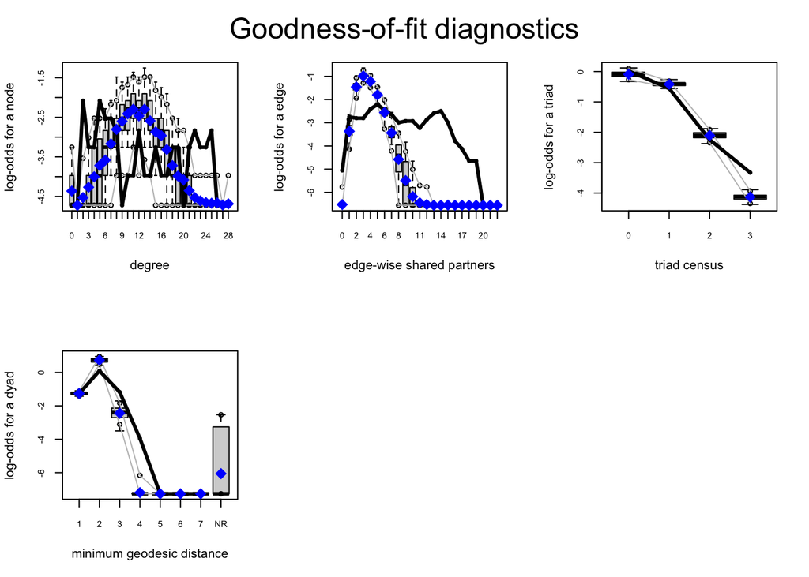

# Conclusion and Limitations

The analysis, given its limitations and aim to go beyond the scope of the previous research on this dataset, are relatively limited. The ERGM model did not return any significant results for the hypothesis. We can therefore not conclude that the prison attribute was significant in developing the co-offending habits of this youth network. However, this is not too surprising given the purpose of this study. As [the original study](https://heinonline.org/HOL/Page?lname=&public=false&collection=journals&handle=hein.journals/jccj31&men_hide=false&men_tab=toc&kind=&page=319) already explored hypotheses on ethnic homophily and triad closure, the aim was to go beyond this topics and in a more exploratory manner test for other singificant features.

In addition, the model should be developed to take into account that the edges in this data set are weighted. This could give a more accurate view of the impact a specific attribute in shaping relationships.

To have further insights into the development of co-offending patterns, one should attempt to collect more data on other gang-networks connected this one. This aspect of connecting co-offending gangs and criminal networks is further explored and justified by [McCuish, Bouchard, and Corrado](https://heinonline.org/HOL/Page?lname=&public=false&collection=journals&handle=hein.journals/jccj31&men_hide=false&men_tab=toc&kind=&page=319). It would also be interesting to work with updated data to assess impacts over time.